# Visualizing caries trend at age 12 from OECD dataset

Sergio Uribe

2018-03-04

```r
library(tidyverse)
df <- read_csv("https://docs.google.com/spreadsheets/d/e/2PACX-1vStv7Pr69DtRKv6Nw6gVBep8hbT3pEeO6B1vNwxK_1DUHgpoTgbuRpZ4SvgtHFQnBZJVGeeQVyRuXZl/pub?gid=1485746444&single=true&output=csv")
head(df)
```

```
## # A tibble: 6 x 3
##   Country        DMFT_12_2006 DentistsPer1000h
##   <chr>                 <dbl>            <dbl>
## 1 Australia             1.10             0.490
## 2 Austria               1.40             0.540
## 3 Belgium               1.10             0.830
## 4 Czech Republic        2.60             0.680
## 5 Denmark               0.800            0.780
## 6 Finland               1.20             0.790
```

```r
df <- df %>%
  mutate(DentistPer10000h = DentistsPer1000h*10)
```

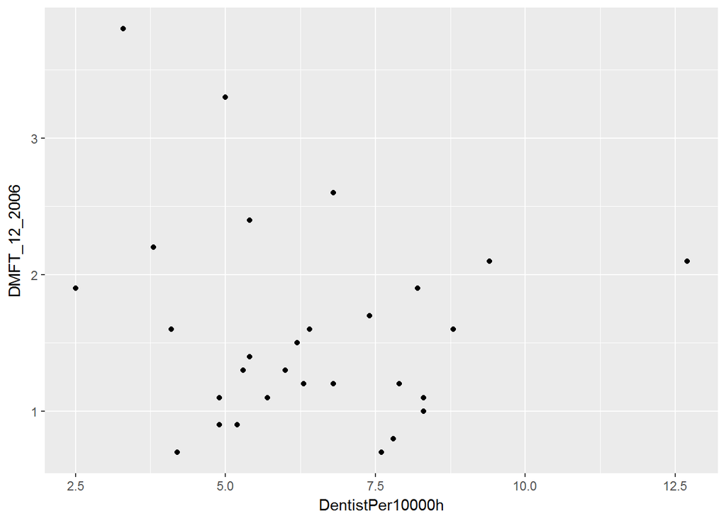

```r
df %>%
  ggplot(aes(x = DentistPer10000h, y = DMFT_12_2006)) +
  geom_point()
```

Is there any trend? We can add a regression line

[figure not shown]

```r
df %>%
  ggplot(aes(x = DentistPer10000h, y = DMFT_12_2006)) +
  geom_point() +
  geom_smooth(method = "gam") # this add a regression
```

To be more realistic, we can use `geom_smooth(method = "loess")`. LOESS LOESS works by trying to identify pattern in the relationship between response and covariates without the user having to specify what form that relationship is.

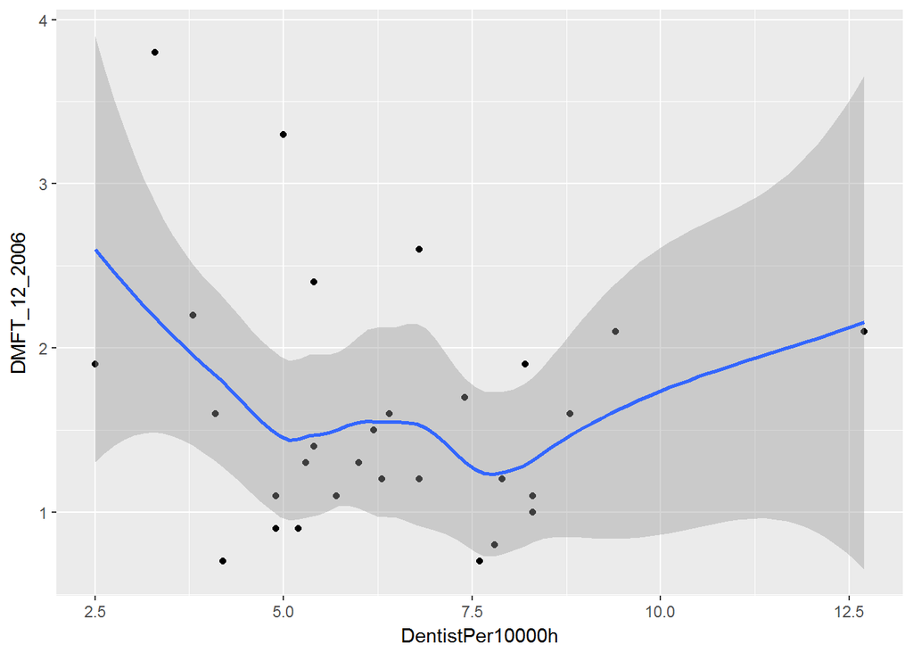

```r
df %>%
  ggplot(aes(x = DentistPer10000h, y = DMFT_12_2006)) +
  geom_point() +
  geom_smooth(method = "loess")
```

Ok, here we have something interesting. Let’s add the labels

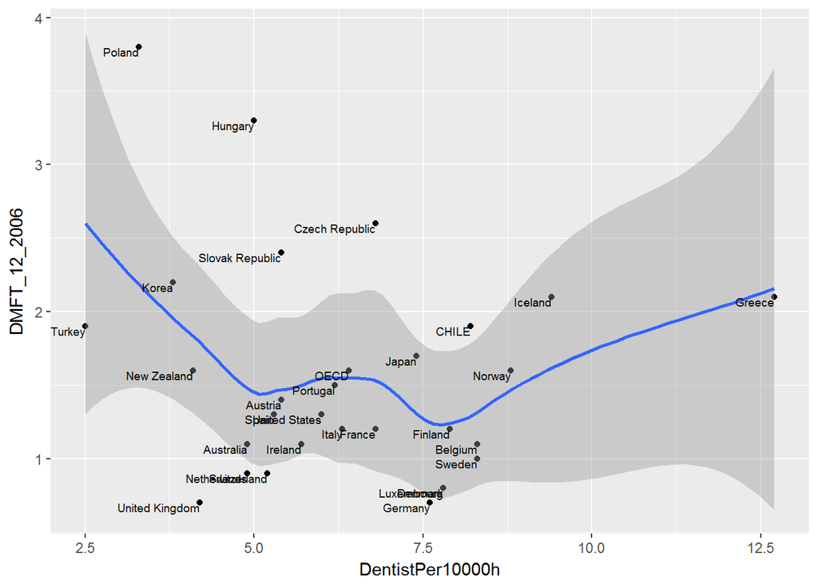

```r
df %>%
  ggplot(aes(x = DentistPer10000h, y = DMFT_12_2006)) +
  geom_point() +
  geom_smooth() +
  geom_text(aes(label = Country), # text to add to any point
            hjust = 1, vjust = 1, # the position
            size = 2.5) # the size of the text
```

**Observations:** - seems that there is some area, between 5 and 7.5 dentists per 10000 inhabitants that is an optimal ratio - Greece is an anomaly: many dentists and caries over the OECD average. - Chile and Iceland have more dentists than the OECD average and more caries. - UK have few dentists and low caries level. Also Netherland and Switzerland.

We can add more information to the graph. For example, let’s add the investment in health per country for the 2006. Hence. download the [data](https://data.oecd.org/healthres/health-spending.htm)

This indicator is presented as a total and by type of financing (“Government/compulsory”, “Voluntary”, “Out-of-pocket”) and is measured as a share of GDP, as a share of total health spending and in USD per capita.

```r
spend2006 <- read_csv("https://docs.google.com/spreadsheets/d/e/2PACX-1vStv7Pr69DtRKv6Nw6gVBep8hbT3pEeO6B1vNwxK_1DUHgpoTgbuRpZ4SvgtHFQnBZJVGeeQVyRuXZl/pub?gid=1551359674&single=true&output=csv")
head(spend2006)
```

```
## # A tibble: 6 x 8
##   LOCATION INDICATOR SUBJECT MEASURE FREQUENCY  TIME    Value `Flag Codes`
##   <chr>    <chr>     <chr>   <chr>   <chr>     <int>    <dbl> <chr>
## 1 AUS      HEALTHEXP TOT     USD_CAP A          2006 3023279. D
## 2 AUT      HEALTHEXP TOT     USD_CAP A          2006 3551471. <NA>
## 3 BEL      HEALTHEXP TOT     USD_CAP A          2006 3158616. <NA>
## 4 CAN      HEALTHEXP TOT     USD_CAP A          2006    3500. <NA>
## 5 CZE      HEALTHEXP TOT     USD_CAP A          2006 1473927. <NA>
## 6 DNK      HEALTHEXP TOT     USD_CAP A          2006 3421532. <NA>
```

```r
codes <- read_csv("https://docs.google.com/spreadsheets/d/e/2PACX-1vStv7Pr69DtRKv6Nw6gVBep8hbT3pEeO6B1vNwxK_1DUHgpoTgbuRpZ4SvgtHFQnBZJVGeeQVyRuXZl/pub?gid=157877590&single=true&output=csv")
head(codes)
```

```
## # A tibble: 6 x 2
##   CODE  Country
##   <chr> <chr>
## 1 ABW   Aruba
## 2 AFG   Afghanistan
## 3 AFRI  Africa
## 4 AGO   Angola
## 5 AIA   Anguilla
## 6 ALB   Albania
```

I will add the code to the first dataset and then join with the second:

```r
df <- inner_join(df, codes, by = "Country")
```

Check

```r
head(df)
```

```
## # A tibble: 6 x 5
##   Country        DMFT_12_2006 DentistsPer1000h DentistPer10000h CODE
##   <chr>                 <dbl>            <dbl>            <dbl> <chr>
## 1 Australia             1.10             0.490             4.90 AUS
## 2 Austria               1.40             0.540             5.40 AUT
## 3 Belgium               1.10             0.830             8.30 BEL
## 4 Czech Republic        2.60             0.680             6.80 CSFR-CZE
## 5 Denmark               0.800            0.780             7.80 DNK
## 6 Finland               1.20             0.790             7.90 FIN
```

```r
spend2006 <- spend2006 %>%
  rename(CODE = LOCATION)
```

heck spend dataset

```r
head(spend2006)
```

```
## # A tibble: 6 x 8
##   CODE  INDICATOR SUBJECT MEASURE FREQUENCY  TIME    Value `Flag Codes`
##   <chr> <chr>     <chr>   <chr>   <chr>     <int>    <dbl> <chr>
## 1 AUS   HEALTHEXP TOT     USD_CAP A          2006 3023279. D
## 2 AUT   HEALTHEXP TOT     USD_CAP A          2006 3551471. <NA>
## 3 BEL   HEALTHEXP TOT     USD_CAP A          2006 3158616. <NA>
## 4 CAN   HEALTHEXP TOT     USD_CAP A          2006    3500. <NA>
## 5 CZE   HEALTHEXP TOT     USD_CAP A          2006 1473927. <NA>
## 6 DNK   HEALTHEXP TOT     USD_CAP A          2006 3421532. <NA>
```

Now merge by CODE column

```r
df <- inner_join(df, spend2006, by = "CODE")
```

Let’s check

```r
head(df)
```

```
## # A tibble: 6 x 12
##   Country   DMFT_12_2006 DentistsPer1000h DentistPer10000h CODE  INDICATOR
##   <chr>            <dbl>            <dbl>            <dbl> <chr> <chr>
## 1 Australia        1.10             0.490             4.90 AUS   HEALTHEXP
## 2 Austria          1.40             0.540             5.40 AUT   HEALTHEXP
## 3 Belgium          1.10             0.830             8.30 BEL   HEALTHEXP
## 4 Denmark          0.800            0.780             7.80 DNK   HEALTHEXP
## 5 Finland          1.20             0.790             7.90 FIN   HEALTHEXP
## 6 France           1.20             0.680             6.80 FRA   HEALTHEXP
## # ... with 6 more variables: SUBJECT <chr>, MEASURE <chr>,
## #   FREQUENCY <chr>, TIME <int>, Value <dbl>, `Flag Codes` <chr>
```

Let’s only the relevant variables

```r
df <- df %>%
  select(Country, DMFT_12_2006, DentistsPer1000h, CODE, Value)
```

Check

```r
head(df)
```

```
## # A tibble: 6 x 5
##   Country   DMFT_12_2006 DentistsPer1000h CODE     Value
##   <chr>            <dbl>            <dbl> <chr>    <dbl>
## 1 Australia        1.10             0.490 AUS   3023279.
## 2 Austria          1.40             0.540 AUT   3551471.
## 3 Belgium          1.10             0.830 BEL   3158616.
## 4 Denmark          0.800            0.780 DNK   3421532.
## 5 Finland          1.20             0.790 FIN   2752177.
## 6 France           1.20             0.680 FRA   3278584.
```

Great.

Now let’s see

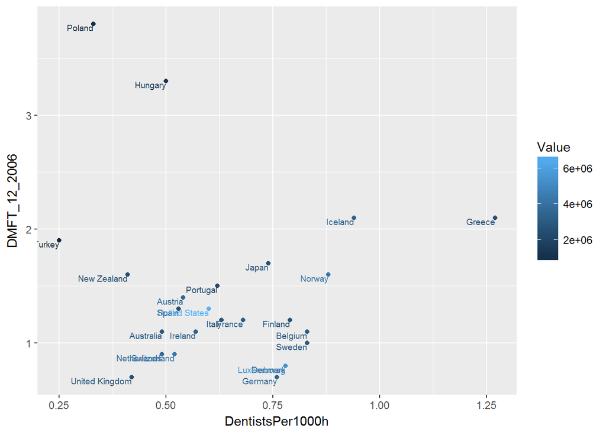

```r
df %>%
  ggplot(aes(x = DentistsPer1000h, y = DMFT_12_2006, color = Value)) +
  geom_point() +
  geom_text(aes(label = Country), # text to add to any point
            hjust = 1, vjust = 1, # the position
            size = 2.5) # the size of the text
```

I would expect some gradient in the plot, but it’s not clear.

Let’s explore the relationship between the spending and the number of dentists

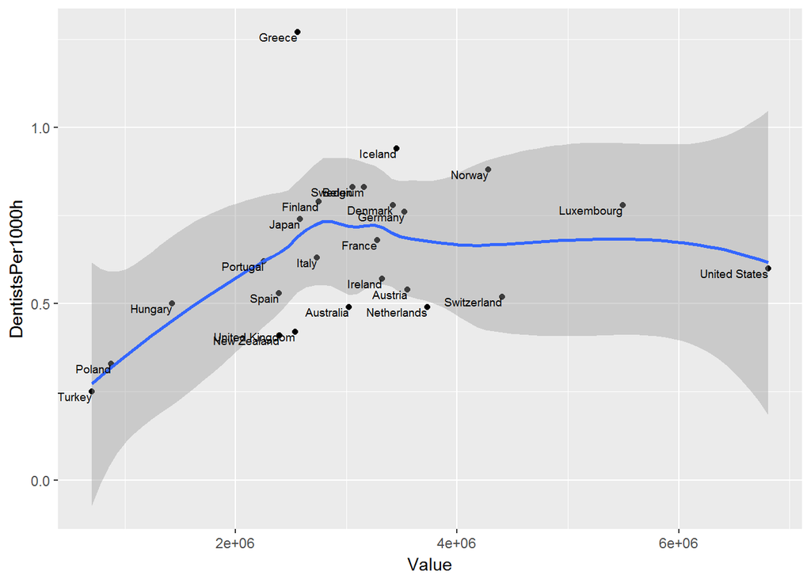

```r
df %>%
  ggplot(aes(x = Value, y = DentistsPer1000h)) +
  geom_point() +
  geom_smooth() +
  geom_text(aes(label = Country), # text to add to any point
            hjust = 1, vjust = 1, # the position
            size = 2.5) # the size of the text
```

**Observations 2** - Seems to be a linear trend below 3e+06 - From 3e+06 seems to be no relationship between spend and numbers of dentists

```r
library(ggrepel)
```

**Disclaimer:** Correlation does not imply causation (except when it does)